# Lecture 14 - Data Transformation 2

Ben Rogers

2022-11-01

## Packages for this lecture

```r
library(tidyverse)
library(babynames)
library(nycflights13)
```

## Last time

- Introduction to data transformation
- Dplyr package functions
  - `select()`
  - `filter()`

## Today

- `arrange()`

## `arrange()`

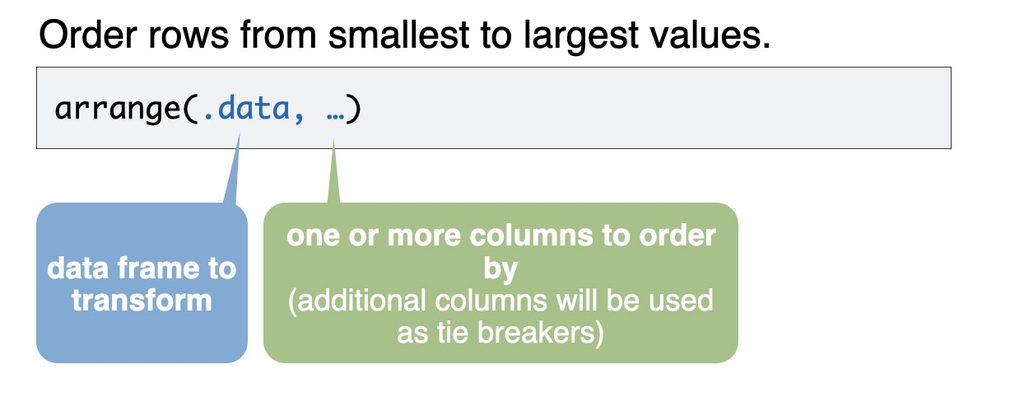

## `arrange()`

`arrange(babynames, n)`

Use `desc()` to re-order by a column in descending order

`arrange(babynames,desc(n))`

Missing values are always sorted at the end:

```r
df <- tibble(x = c(5, 2, NA))
arrange(df, x)
```

```
## # A tibble: 3 × 1
##       x
##   <dbl>
## 1     2
## 2     5
## 3    NA
```

## `arrange()`

```r
arrange(df, desc(x))
```

```
## # A tibble: 3 × 1
##       x
##   <dbl>
## 1     5
## 2     2
## 3    NA
```

## Combining multiple operations with pipe `%>%`

```r
babynames %>% filter(n == 1000)
 filter(babynames,n == 1000)
```

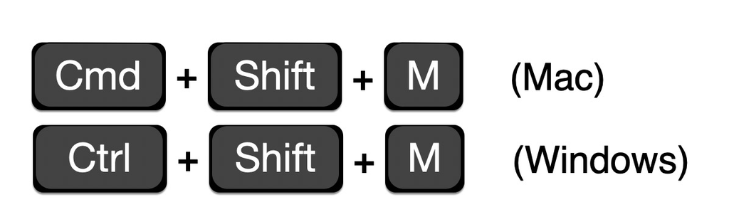

## Piping

Suppose we wish to:

1. Filter `babynames` to just boys born in 2015
2. Select the `name` and `n` columns from the result
3. Arrange those columns so that the most popular names appear near the top.

## Piping

Suppose we wish to:

1. Filter `babynames` to just boys born in 2015
2. Select the `name` and `n` columns from the result
3. Arrange those columns so that the most popular names appear near the top.

```r
arrange(select(filter(babynames, year == 2015,
  sex == "M"), name, n), desc(n))
```

## Piping

Suppose we wish to:

1. Filter `babynames` to just boys born in 2015
2. Select the `name` and `n` columns from the result
3. Arrange those columns so that the most popular names appear near the top.

```r
boys_2015 <- filter(babynames, year == 2015, sex == "M")
boys_2015 <- select(boys_2015, name, n)
boys_2015 <- arrange(boys_2015, desc(n))
```

## Piping

Suppose we wish to:

1. Filter `babynames` to just boys born in 2015
2. Select the `name` and `n` columns from the result
3. Arrange those columns so that the most popular names appear near the top.

```r
babynames %>%
  filter(year == 2015, sex == "M") %>%
  select(name, n) %>%
  arrange(desc(n))
```

## All three work

```r
# Method 1
arrange(select(filter(babynames, year == 2015,
  sex == "M"), name, n), desc(n))

# Method 2
boys_2015 <- filter(babynames, year == 2015, sex == "M")
boys_2015 <- select(boys_2015, name, n)
boys_2015 <- arrange(boys_2015, desc(n))

# Method 3
babynames %>%
  filter(year == 2015, sex == "M") %>%
  select(name, n) %>%
  arrange(desc(n))
```

## With ggplot

For ggplot, you should use `+` instead of `%>%`

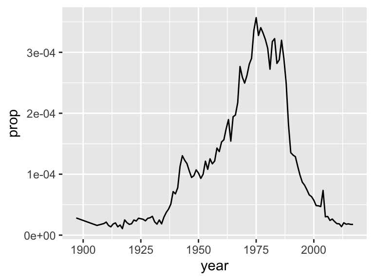

```r
babynames  %>%
  filter(sex == "F",name=="Michael") %>%
  ggplot()+
  geom_line(aes(x=year,y=prop))
```

## Your turn

- Use %>% to write a sequence of functions that:

  ```
  - Filters babynames to the girls that were born in 2017, then…
  - Selects the name and n columns, then…
  - Arranges the results so that the most popular names are near the top.
  ```

- Use %>% to write a sequence of functions that:

  ```
  - Trim babynames to just the rows that contain any name and sex
  - Trim the result to just the columns that will appear in your graph
    (not strictly necessary, but useful practice)
  - Plot the results as a line graph with year on the x axis and prop on the y axis
  ```

Plotting groups

```r
babynames %>%
  filter(name == "Michael") %>%
  ggplot() +
    geom_point(mapping = aes(year, prop))

babynames %>%
  filter(name == "Michael") %>%
  ggplot() +
    geom_line(mapping = aes(year, prop))

babynames %>%
  filter(name == "Michael") %>%
  ggplot() +
    geom_line(mapping = aes(year, prop, group = sex))

babynames %>% filter(name == "Michael") %>%
  ggplot() +
    geom_line(mapping = aes(year, prop)) +
    facet_wrap(~ sex, scales = "free_y")
```

## Summarize

`babynames %>% summarize(total = sum(n), max = max(n))`

summarize() function creates one or more scalar variables summarizing the variables of a tibble.

n() returns the number of rows in a dataset

n_disinct() returns the number of distinct values in a variable

`babynames %>% summarize(n = n(), nname = n_distinct(name))`

## Your turn

- Extract the rows where name == “Khaleesi”. Then use summarize() and sum() and min() to find:
  - The total number of children named Khaleesi
  - The first year Khaleesi appeared in the data

## Grouping

Can we do the things in the previous exercise for all names?

Let’s work on another dataset to learn group_by()

```r
pollution <- tribble(
       ~city,   ~size, ~amount,
  "New York", "large",      23,
  "New York", "small",      14,
    "London", "large",      22,
    "London", "small",      16,
   "Beijing", "large",      121,
   "Beijing", "small",      56
)
```

```r
pollution %>%
 summarize(mean = mean(amount), sum = sum(amount), n = n())
```

```
## # A tibble: 1 × 3
##    mean   sum     n
##   <dbl> <dbl> <int>
## 1    42   252     6
```

```r
pollution %>%
  group_by(city) %>%
  summarize(mean = mean(amount), sum = sum(amount), n = n())
```

```
## # A tibble: 3 × 4
##   city      mean   sum     n
##   <chr>    <dbl> <dbl> <int>
## 1 Beijing   88.5   177     2
## 2 London    19      38     2
## 3 New York  18.5    37     2
```

## `group_by()`

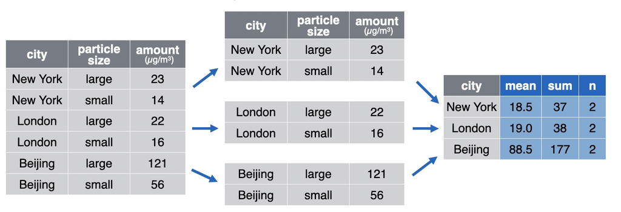

```r
 pollution %>%
  group_by(city, size) %>%
  summarize(mean = mean(amount), sum = sum(amount), n = n())
```

```
## # A tibble: 6 × 5
## # Groups:   city [3]
##   city     size   mean   sum     n
##   <chr>    <chr> <dbl> <dbl> <int>
## 1 Beijing  large   121   121     1
## 2 Beijing  small    56    56     1
## 3 London   large    22    22     1
## 4 London   small    16    16     1
## 5 New York large    23    23     1
## 6 New York small    14    14     1
```

```r
weather %>%
  group_by(month) %>%
  summarize(mean = mean(temp, na.rm = TRUE),
            std_dev = sd(temp, na.rm = TRUE))
```

```
## # A tibble: 12 × 3
##    month  mean std_dev
##    <int> <dbl>   <dbl>
##  1     1  35.6   10.2
##  2     2  34.3    6.98
##  3     3  39.9    6.25
##  4     4  51.7    8.79
##  5     5  61.8    9.68
##  6     6  72.2    7.55
##  7     7  80.1    7.12
##  8     8  74.5    5.19
##  9     9  67.4    8.47
## 10    10  60.1    8.85
## 11    11  45.0   10.4
## 12    12  38.4    9.98
```

```r
diamonds %>%
  group_by(cut) %>%
  summarize(avg_price = mean(price))
```

```
## # A tibble: 5 × 2
##   cut       avg_price
##   <ord>         <dbl>
## 1 Fair          4359.
## 2 Good          3929.
## 3 Very Good     3982.
## 4 Premium       4584.
## 5 Ideal         3458.
```

```r
babynames %>%
  group_by(sex) %>%
  summarize(total = sum(n))
```

```
## # A tibble: 2 × 2
##   sex       total
##   <chr>     <int>
## 1 F     172371079
## 2 M     175749438
```

Use ungroup to remove grouping criteria from a data frame.

```r
babynames %>%
  group_by(sex) %>%
  ungroup() %>%
  summarize(total = sum(n))
```

```
## # A tibble: 1 × 1
##       total
##       <int>
## 1 348120517
```

## Your turn

Display the ten most popular name and sex combinations. Compute popularity as the total number of children with a given name and sex.

```
- Use group_by() to calculate the total number of children born for every year.
- Plot the results as a line graph: year vs. total.
```